# Final Report

Jack Freier and Jackson Henningfield

5/3/2020

Abstract

This report takes an in-depth look at the many factors that influence hotel booking cancellations. Using data that includes both a series of potential explanatory variables and known observations, we build and train five models that predict the probability of a guest cancelling their hotel reservation. We then evaluate these models individually and present our findings, justifying our selection of the best model with several performance metrics as well as providing a detailed interpretation of the results.

# 1 Introduction

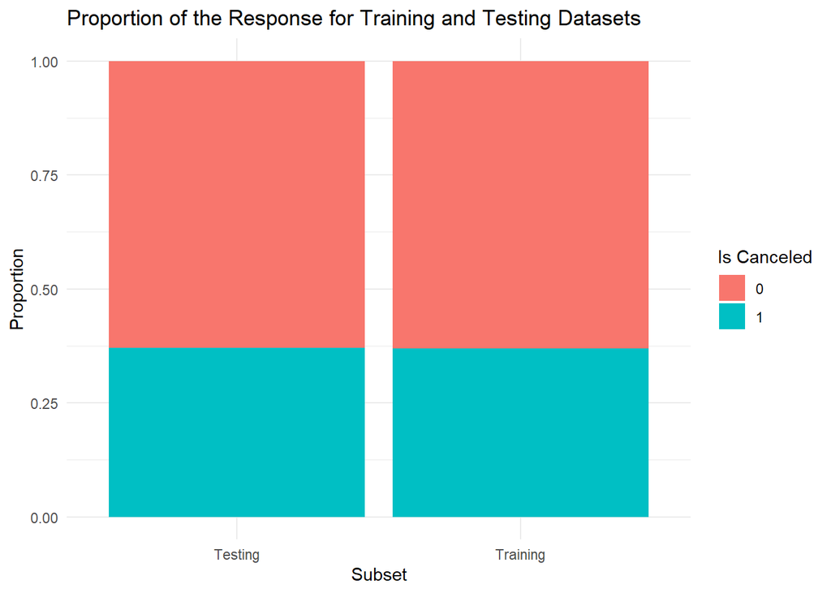

Figure 1.1: Proportion of the `is_canceled` response variable for both the training and testing datasets. The exact proportion of cancelled hotel bookings for both subsets is 0.3704.

# 2 Exploratory Work

In order to get a broad sense of how each variable influences our response, we first create exploratory plots for hotel cancellations. These plots are split into two categories, one comprising numeric predictors and the other categorical predictors. Each of these visualizations gives insight into how the particular variable of interest proportionally influences cancellations.

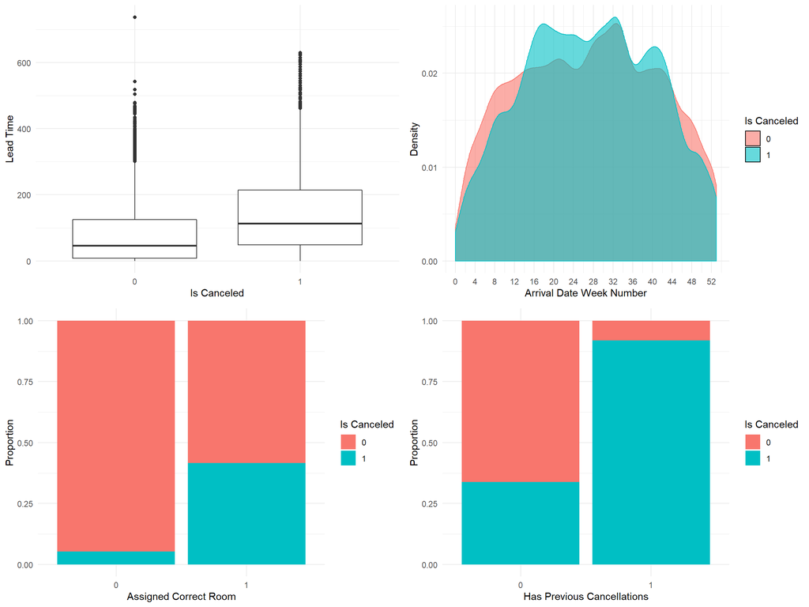

Figure 2.1: Example exploratory plots for four variables of interest (two numeric, two categorical). (Upper left) The median lead time for cancelled bookings is substantially higher than non-cancelled bookings. (Upper right) There are proportionally more cancellations from week 14 to week 44. (Lower left) There are proportionally more cancellations for bookings where the guest was assigned the correct room. (Lower right) There are proportionally more cancellations for guests who have previously cancelled a hotel booking.

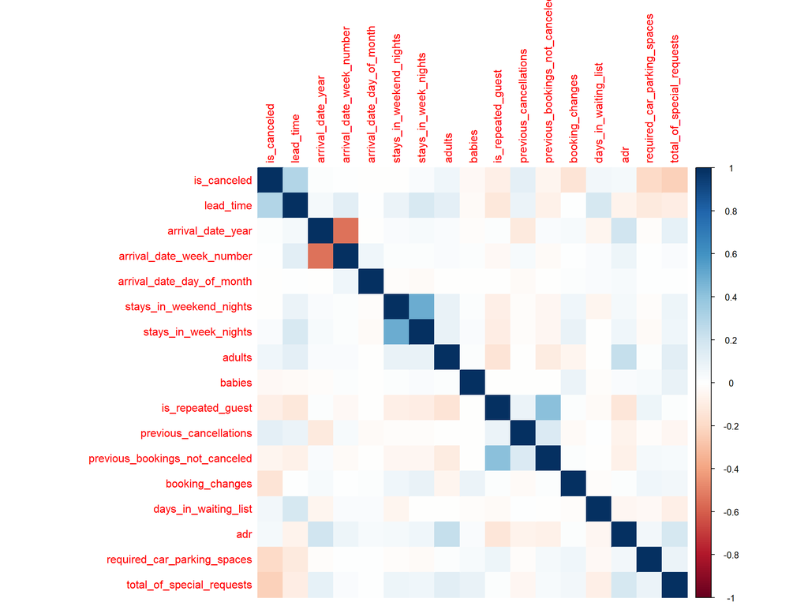

Figure 2.2: Plot detailing the correlation between individual numeric variables included in the dataset. The opacity of the square signifies the magnitude, with blue representing positive correlation and red representing negative correlation.

Lastly, before beginning the modeling process, we manipulate or remove several problematic variables included in the dataset. These variables are characterized by a series of issues, such as extreme crowding of particular categorical levels or numeric values (while other levels or values are very sparsely populated). To account for these deficiencies, we create new variables that aggregate information stored in the previous variables’ levels (i.e. turning the `country` variable into a `region` variable based on geographic boundaries).

# 3 Modeling Process

Our goal is to create the “best” possible model that is fit for predicting whether or not a particular reservation is canceled or not. We define the “best” possible model as that which has the highest testing accuracy, since we can measure a model’s predictive power based on its performance on the testing dataset.

In our study, we created five models with `is_canceled` as our response variable. These five models (logistic regression with seven variables, logistic regression with all variables, LASSO, a classifcation tree, and a random forest) and their outputs can be seen below. We trained each model on the training set and calculated the training and cross-validated accuracies as well as the areas under each ROC curve. The code chunks below give a run down of all of these metrics, all of which assisted us in our decision to isolate one model as the best one.

Our first model output here is a logistic regression that included our seven most important variables as shown in the random forest variable importance plot (shown later in this report). This model was created in order to ease the interpretation; since this model only has 7 variables compared to the full logistic model, with 14 variables, we thought that this would be a good example of how the number of predictors in a model affects its overall performance.

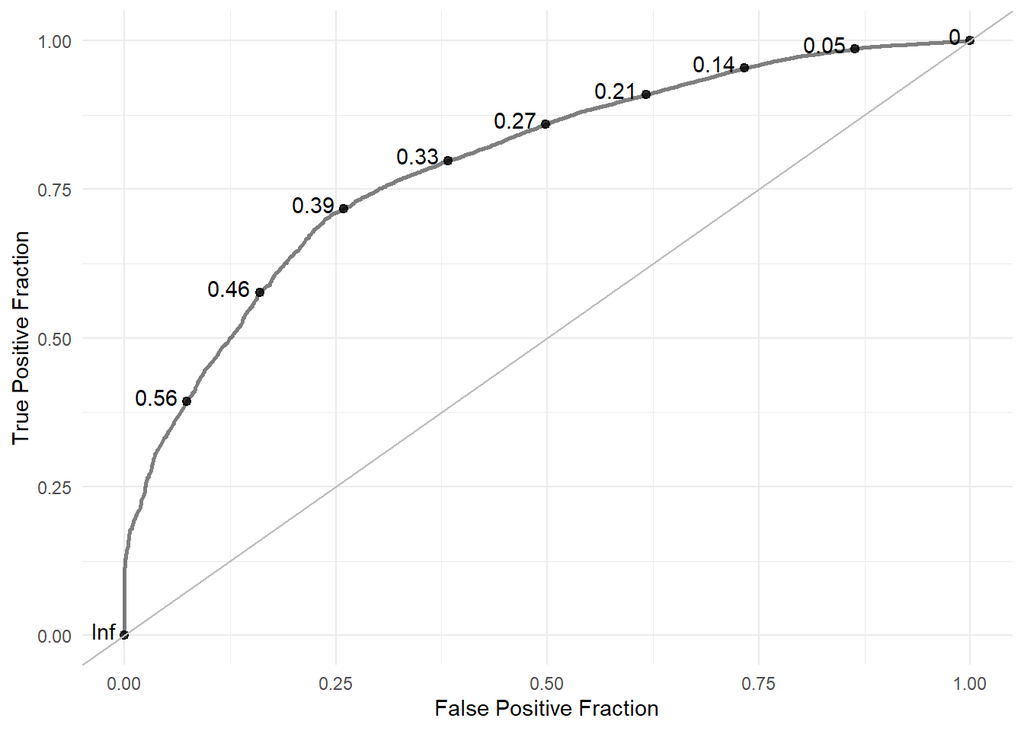

Our second model is the full logistic regression model with all of our predictors. This model was one of our poorest performing models in terms of the testing accuracy and the testing AUC. The final results table at the end of the paper confirms this as well.

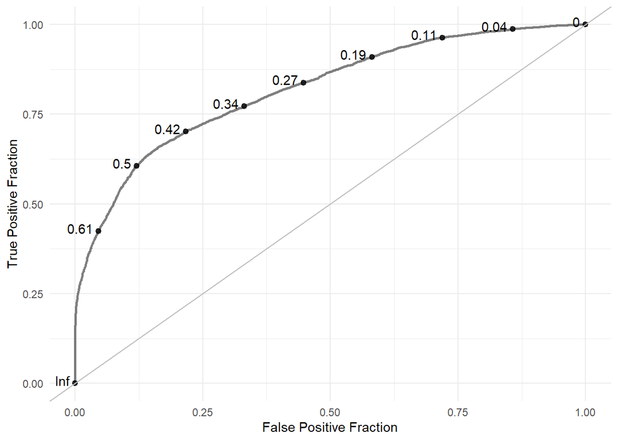

Our third model was a LASSO model where we used all of the predictors in our training set. It had similar results to our full logistic regression model. As seen in the lambda vs. accuracy graph, the accuracy quickly drops off after a cp of .01.

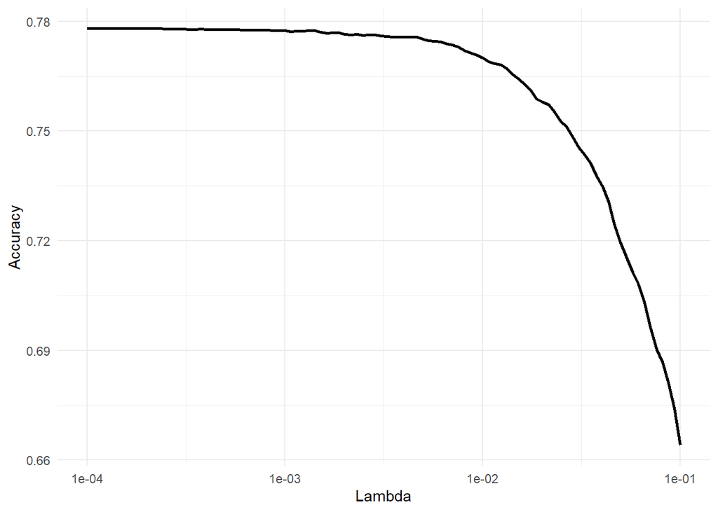

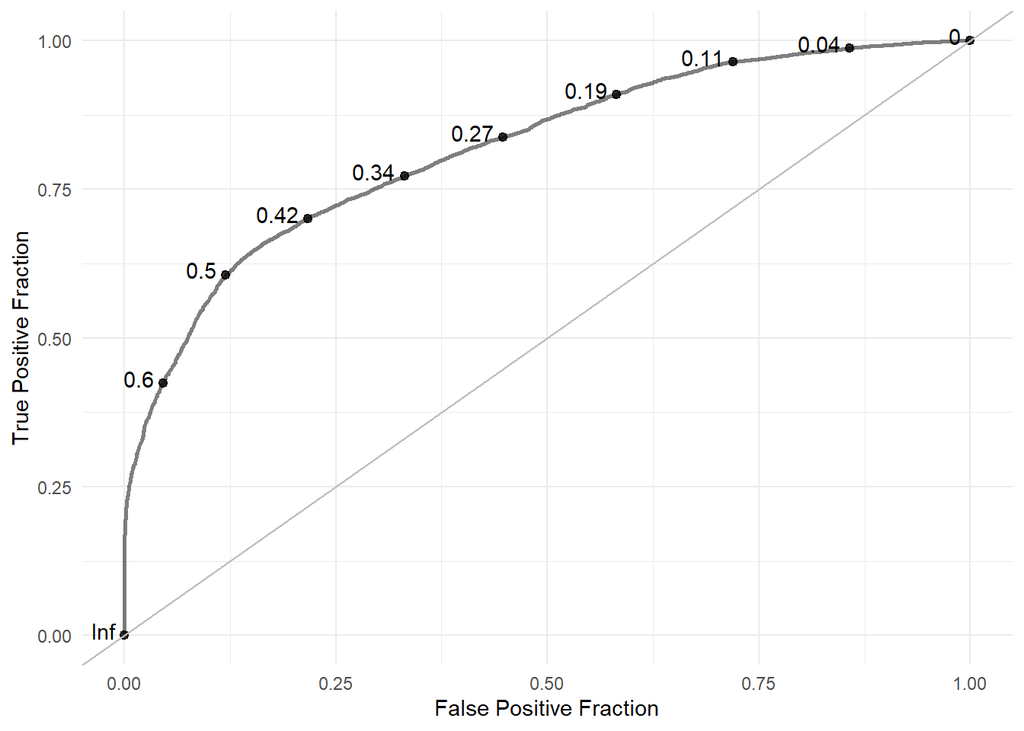

The fourth model was a classfication tree; this model was our second best model in terms of performance and its accuracy. The cp vs. accuracy plot tells us that the accuracy of our model dips rather swiftly past the best tune cp of 0.0001456348. Furthermore, the ROC curve is bowed out in a way that shows that the true positive rate is greater than the false positive rate at the certain cp points on the graph such as 0.44, 0.35, and 0.26 and so forth.

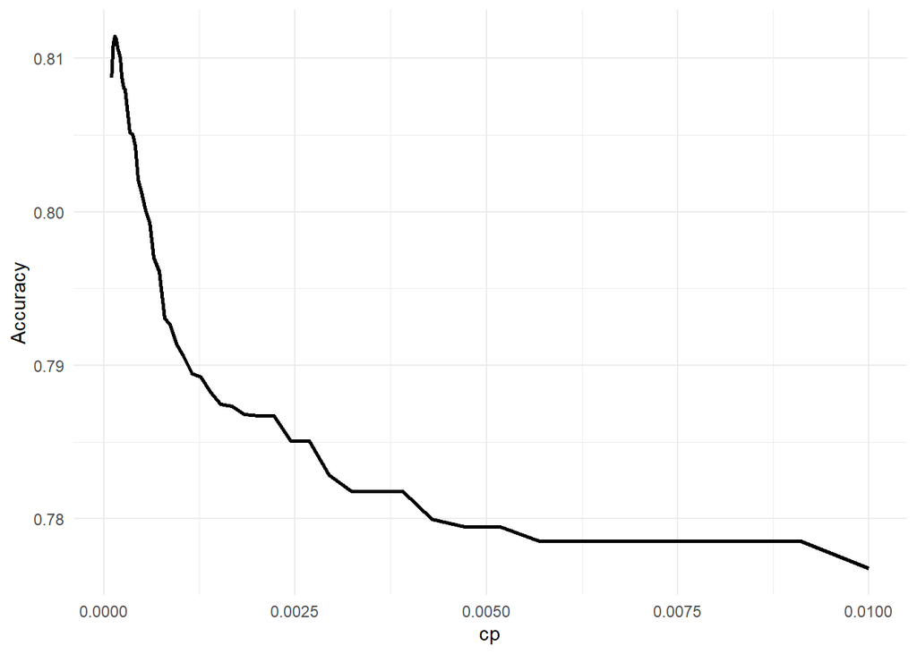

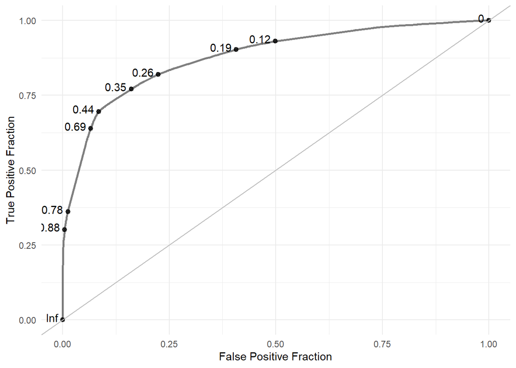

The fifth and final model is our best performing one: the random forest. This model has the highest accuracy and the most bowed out ROC curve which is another signal of the high perforamce capability. The OOB error vs. the number of trees graph tells us that the error flattens out at about forty trees. Overall, this error is rather low (less than 20%), and we know this model isn’t overfitted on the training set since its testing accuracy is also fairly high (see Results and Next Steps).

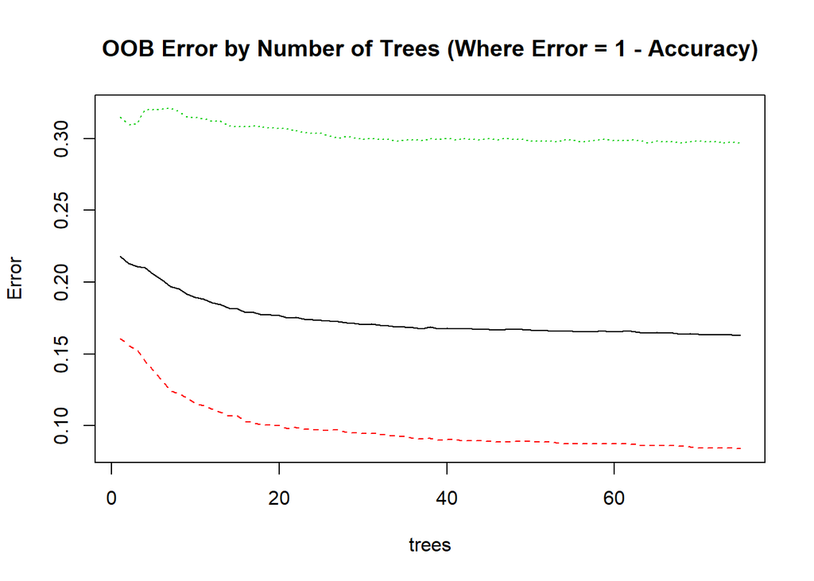

```
## Confusion Matrix and Statistics
##
##           Reference
## Prediction     0     1
##          0 34424  6565
##          1  3159 15547
##
##                Accuracy : 0.8371
##                  95% CI : (0.8341, 0.8401)
##     No Information Rate : 0.6296
##     P-Value [Acc > NIR] : < 2.2e-16
##
##                   Kappa : 0.6393
##
##  Mcnemar's Test P-Value : < 2.2e-16
##
##             Sensitivity : 0.7031
##             Specificity : 0.9159
##          Pos Pred Value : 0.8311
##          Neg Pred Value : 0.8398
##              Prevalence : 0.3704
##          Detection Rate : 0.2604
##    Detection Prevalence : 0.3134
##       Balanced Accuracy : 0.8095
##
##        'Positive' Class : 1
##
```

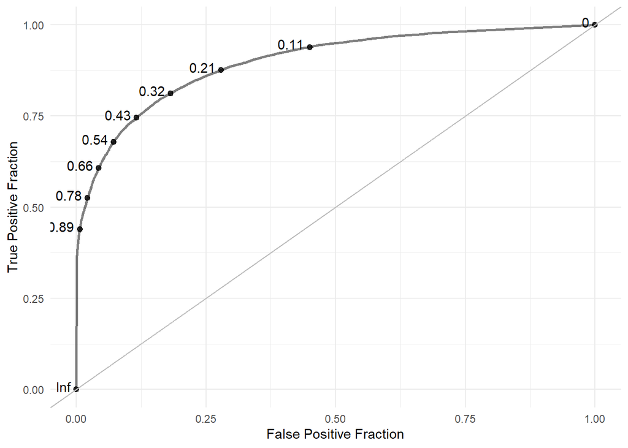

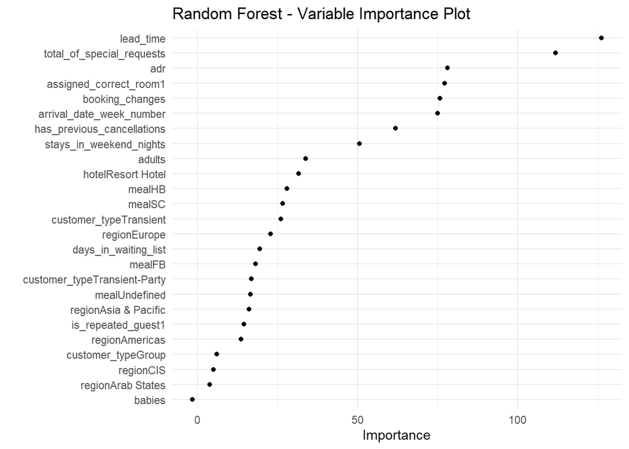

Figure 3.1: Variable importance plot for our random forest model. Illustrates the relative importance of each variable utilized in the random forest. The two variables that stand out the most are `lead_time` and `total_of_special_requests`, with each being dramatically more important than the subsequent four variables.

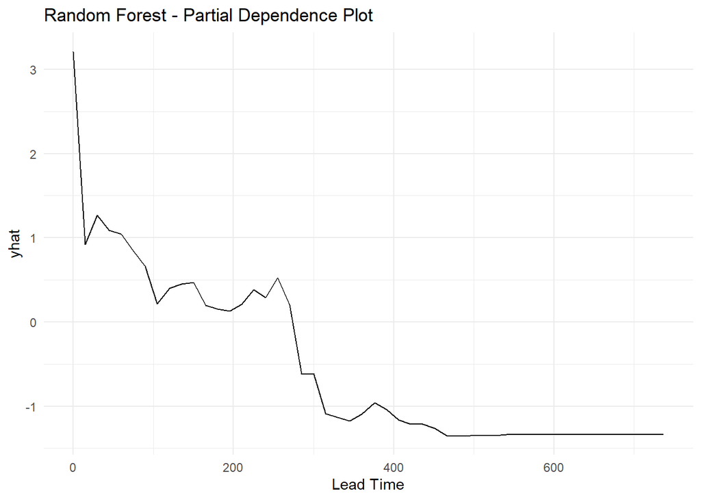

Figure 3.2: Partial dependence plot for the `lead_time` variable. Larger lead times tend to decrease the probability of a cancellation whereas shorter lead times tend to increase it.

# 4 Results and Next Steps

| Model | Training Acc. | CV Acc. | AUC | Test Acc. | Test ACU |
| --- | --- | --- | --- | --- | --- |
| hotel_logistic_7 | 0.7355 | 0.7353 | 0.7931 | 0.7363 | 0.7159 |
| hotel_logistic_all | 0.7785 | 0.7779 | 0.8191 | 0.7779 | 0.7325 |
| hotel_lasso | 0.7785 | 0.7781 | 0.8190 | 0.7778 | 0.7325 |
| hotel_tree | 0.8343 | 0.8114 | 0.8796 | 0.8128 | 0.7681 |
| hotel_randf_oob | 0.8358 | 0.8357 | 0.8984 | 0.8375 | 0.7859 |

After completing training and testing for our five models and analysing their summaries, confusion matricies, and ROC plots, we came to the conclusion that the random forest is our best model; it not only performs the best on the training dataset, but also performs exceptionally well on the portion of the data reserved for testing. In terms of interpretaion, this tree is structually complex due to the number of variables that we allow for; however, combining the natural intuition of trees along with the information that variable importance plots and partial dependence plots give us, we are able to provide an intuitive representation of our hotel booking situation.

As for future extentions of our work, the idea of clustering caught our eye as a possible next step to further hone our model’s predictive performance. Because hotel bookings dataset is quite large (over 100,000 observations), it is a good candidate for additional inquiries. Using non-supervised machine learning techniques, like hierarchical or k-means clustering, would allow us to divide this dataset into like groups, which could in turn assist in making models that focus on certain elements of a hotel reservation.